# MIMIC-III Patients Table

efg | 2018-12-30

Online [info about the patients table](https://mimic.physionet.org/mimictables/patients/).

According to [schema](https://mit-lcp.github.io/mimic-schema-spy/tables/patients.html) these tables are children of the patients table:

- admissions
- callout
- chartevents
- cptevents
- datetimeevents
- diagnoses_icd
- drgcodes
- icustays
- inputevents_cv
- inputevents_mv
- labevents
- microbiologyevents
- noteevents
- outputevents
- prescriptions
- procedureevents_mv
- procedures_icd
- services
- transfers

NOTE: At this time neither RPostgreSQL nor Rpostgres package works correctly with dates in all cases.

# 1 Setup

## 1.1 Packages

```r
library(DBI)
library(RPostgres)
library(tidyverse)
```

```r
library(dbplyr, warn.conflicts=FALSE)
library(kableExtra)
library(ggplot2)
```

## 1.2 Helper function

```r
Show <- function(data)
{
  data            %>%
  kable("html")   %>%
  kable_styling(bootstrap_options = c("striped", "bordered", "condensed"),
                position = "left", full_width = FALSE)
}
```

## 1.3 Open database

```r
MimicDB <- dbConnect(RPostgres::Postgres(),
                     dbname   = "mimic",
                     user     = Sys.getenv("MIMIC_User"),
                     password = Sys.getenv("MIMIC_Password"),
                     bigint   = "integer",
                     options  = "-c search_path=mimiciii")

plotCaptionLeft  <- "MIMIC-III v1.4"
plotCaptionRight <- paste("efg", format(Sys.time(), "%Y-%m-%d"))
```

# 2 List of fields in a patients table

```r
dbListFields(MimicDB, "patients")
```

```
[1] "row_id"      "subject_id"  "gender"      "dob"         "dod"
[6] "dod_hosp"    "dod_ssn"     "expire_flag"
```

# 3 Sample patients

```r
patients <- tbl(MimicDB, in_schema("mimiciii", "patients"))

patients          %>%
  head(10)        %>%
  Show()
```

| row_id | subject_id | gender | dob | dod | dod_hosp | dod_ssn | expire_flag |
| --- | --- | --- | --- | --- | --- | --- | --- |
| 234 | 249 | F | 2075-03-13 | NA | NA | NA | 0 |
| 235 | 250 | F | 2164-12-27 | 2188-11-22 | 2188-11-22 | NA | 1 |
| 236 | 251 | M | 2090-03-15 | NA | NA | NA | 0 |
| 237 | 252 | M | 2078-03-06 | NA | NA | NA | 0 |
| 238 | 253 | F | 2089-11-26 | NA | NA | NA | 0 |
| 239 | 255 | M | 2109-08-05 | NA | NA | NA | 0 |
| 240 | 256 | M | 2086-07-31 | NA | NA | NA | 0 |
| 241 | 257 | F | 2031-04-03 | 2121-07-08 | 2121-07-08 | 2121-07-08 | 1 |
| 242 | 258 | F | 2124-09-19 | NA | NA | NA | 0 |
| 243 | 260 | F | 2105-03-23 | NA | NA | NA | 0 |

# 4 Record count

```r
patients             %>%
  summarize(n = n()) %>%
  Show()
```

| n |
| --- |
| 46520 |

# 5 Fields

## 5.1 row_id

```r
patients                                         %>%
  summarize(minRowID = min(row_id, na.rm=TRUE),
            maxRowID = max(row_id, na.rm=TRUE))  %>%
  collect()                                      %>%
  Show()
```

| minRowID | maxRowID |
| --- | --- |
| 1 | 46520 |

## 5.2 subject_id

`subject_id` is a unique identifier that specifies an individual patient.

```r
patients                                                 %>%
  summarize(minSubjectID = min(subject_id, na.rm=TRUE),
            maxSubjectID = max(subject_id, na.rm=TRUE))  %>%
  Show()
```

| minSubjectID | maxSubjectID |
| --- | --- |
| 2 | 99999 |

There are two groups of `subject _id` ranges.

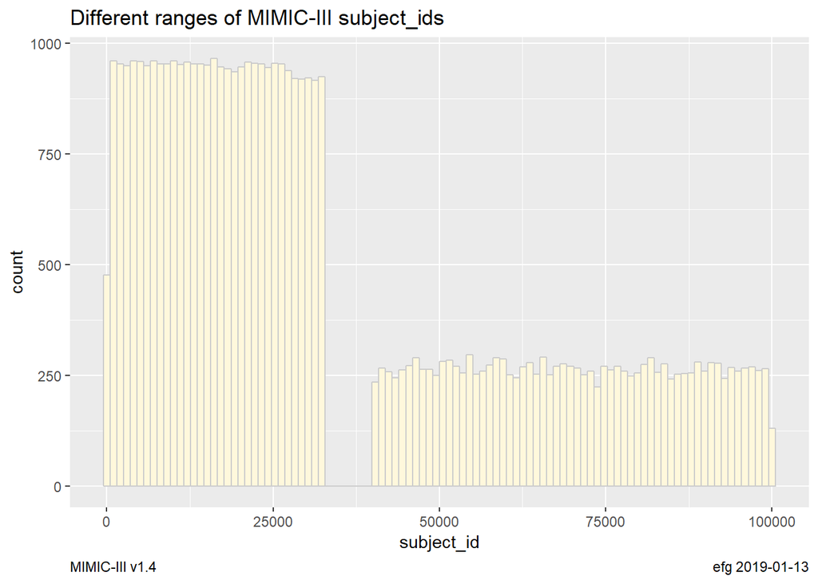

```r
patients                %>%
  select(subject_id)    %>%
  collect               %>%
  ggplot(aes(x=subject_id))                                 +
  geom_histogram(fill="cornsilk", color="grey80", bins=100) +
  labs(title = "Different ranges of MIMIC-III subject_ids",
       caption=c(plotCaptionLeft, plotCaptionRight))        +
  theme(plot.caption = element_text(hjust=c(0.0,1.0)))
```

## 5.3 gender

```r
patients            %>%
  group_by(gender)  %>%
  count()           %>%
  Show()
```

| gender | n |
| --- | --- |
| M | 26121 |
| F | 20399 |

## 5.4 dob (date of birth) counts

[Online info](https://mimic.physionet.org/mimictables/patients/): `

*`DOB` is the date of birth of the given patient. Patients who are older than 89 years old at any time in the database have had their date of birth shifted to obscure their age and comply with HIPAA. The shift process was as follows: the patient’s age at their first admission was determined. The date of birth was then set to exactly 300 years before their first admission.*

```r
dobByYearMonth <-
  patients                                 %>%
  mutate(Year  = date_part("year",  dob),
         Month = date_part("month", dob))  %>%
  select(Year, Month)                      %>%
  group_by(Year, Month)                    %>%
  count()  %>%
  ungroup()                                %>%
  collect()                                %>%
  arrange(Year, Month)                     %>%
  spread(Month, n, fill=0)
```

Counts of MIMIC-III dates of birth (dob) by year and month

```r
dobByYearMonth                     %>%
  Show()                           %>%
  scroll_box(height = "500px")
```

| Year | 1 | 2 | 3 | 4 | 5 | 6 | 7 | 8 | 9 | 10 | 11 | 12 |
| --- | --- | --- | --- | --- | --- | --- | --- | --- | --- | --- | --- | --- |
| 1800 | 0 | 0 | 0 | 0 | 0 | 0 | 4 | 2 | 3 | 2 | 1 | 1 |
| 1801 | 1 | 4 | 2 | 0 | 1 | 0 | 3 | 3 | 2 | 3 | 0 | 1 |
| 1802 | 5 | 2 | 4 | 3 | 0 | 3 | 3 | 3 | 1 | 2 | 4 | 3 |
| 1803 | 1 | 3 | 5 | 1 | 2 | 0 | 3 | 0 | 2 | 4 | 0 | 1 |
| 1804 | 2 | 5 | 1 | 3 | 3 | 3 | 1 | 0 | 4 | 0 | 2 | 2 |
| 1805 | 4 | 1 | 0 | 1 | 2 | 0 | 3 | 1 | 2 | 0 | 2 | 1 |
| 1806 | 0 | 3 | 2 | 3 | 2 | 0 | 2 | 1 | 2 | 1 | 0 | 3 |
| 1807 | 2 | 1 | 2 | 0 | 4 | 1 | 3 | 2 | 4 | 0 | 0 | 2 |
| 1808 | 5 | 0 | 3 | 0 | 0 | 2 | 2 | 1 | 3 | 2 | 2 | 1 |
| 1809 | 1 | 4 | 4 | 4 | 2 | 2 | 3 | 1 | 2 | 4 | 4 | 0 |
| 1810 | 4 | 1 | 0 | 0 | 2 | 0 | 2 | 1 | 2 | 0 | 0 | 1 |
| 1811 | 0 | 1 | 0 | 1 | 4 | 0 | 1 | 0 | 1 | 4 | 1 | 1 |
| 1812 | 0 | 1 | 3 | 2 | 4 | 0 | 2 | 1 | 8 | 2 | 2 | 3 |
| 1813 | 2 | 0 | 2 | 1 | 1 | 0 | 0 | 0 | 2 | 1 | 1 | 2 |
| 1814 | 0 | 0 | 1 | 1 | 2 | 0 | 1 | 4 | 1 | 2 | 0 | 2 |
| 1815 | 2 | 1 | 0 | 0 | 0 | 1 | 0 | 0 | 1 | 2 | 3 | 1 |
| 1816 | 2 | 1 | 3 | 0 | 3 | 1 | 0 | 0 | 1 | 1 | 0 | 0 |
| 1817 | 4 | 2 | 1 | 1 | 2 | 3 | 3 | 1 | 1 | 3 | 2 | 1 |
| 1818 | 1 | 0 | 2 | 0 | 4 | 3 | 5 | 0 | 0 | 4 | 0 | 0 |
| 1819 | 1 | 3 | 1 | 3 | 1 | 3 | 0 | 2 | 3 | 0 | 2 | 1 |
| 1820 | 3 | 2 | 2 | 1 | 1 | 1 | 2 | 2 | 4 | 0 | 1 | 3 |
| 1821 | 2 | 0 | 3 | 0 | 1 | 0 | 3 | 0 | 1 | 6 | 1 | 0 |
| 1822 | 2 | 4 | 1 | 2 | 2 | 1 | 2 | 3 | 1 | 1 | 0 | 1 |
| 1823 | 1 | 1 | 1 | 0 | 2 | 4 | 4 | 3 | 1 | 0 | 1 | 2 |
| 1824 | 0 | 0 | 2 | 1 | 2 | 2 | 0 | 1 | 3 | 2 | 2 | 0 |
| 1825 | 2 | 4 | 0 | 4 | 3 | 1 | 0 | 1 | 1 | 0 | 1 | 1 |
| 1826 | 1 | 2 | 1 | 3 | 1 | 1 | 0 | 0 | 1 | 0 | 1 | 1 |
| 1827 | 1 | 1 | 2 | 0 | 0 | 2 | 5 | 0 | 1 | 0 | 3 | 3 |
| 1828 | 1 | 1 | 1 | 1 | 2 | 1 | 4 | 0 | 2 | 1 | 0 | 5 |
| 1829 | 3 | 2 | 2 | 1 | 1 | 1 | 4 | 0 | 0 | 2 | 2 | 2 |

[output cut: 262 more lines]

The expectation is the distribution by year and month should be fairly random.

`dob` spreads over years 1800 to 1901 and 2012 to 2201 as part of deindentification process.

## 5.5 expire_flag

*`EXPIRE_FLAG` is a binary flag that indicates whether the patient died, i.e. whether DOD is null or not. These deaths include both deaths within the hospital (DOD_HOSP) and deaths identified by matching the patient to the social security master death index (DOD_SSN).*

```r
patients                                                 %>%
  group_by(expire_flag)                                  %>%
  summarize(n = n())                                     %>%
  Show()
```

| expire_flag | n |
| --- | --- |
| 0 | 30761 |
| 1 | 15759 |

## 5.6 dod (date of death) counts

*`DOD` is the date of death for the given patient.*

```r
dodByYearMonth <-
  patients                                 %>%
  filter(expire_flag == 1)                 %>%
  mutate(Year  = date_part("year",  dod),
         Month = date_part("month", dod))  %>%
  select(Year, Month)                      %>%
  group_by(Year, Month)                    %>%
  count()                                  %>%
  ungroup()                                %>%
  collect()                                %>%
  arrange(Year, Month)                     %>%
  spread(Month, n, fill=0)
```

Counts of MIMIC-III dates of death (dod) by year and month

```r
dodByYearMonth                 %>%
  Show()                       %>%
  scroll_box(height = "500px")
```

| Year | 1 | 2 | 3 | 4 | 5 | 6 | 7 | 8 | 9 | 10 | 11 | 12 |
| --- | --- | --- | --- | --- | --- | --- | --- | --- | --- | --- | --- | --- |
| 2100 | 0 | 0 | 0 | 0 | 0 | 1 | 1 | 2 | 9 | 7 | 5 | 8 |
| 2101 | 8 | 8 | 10 | 6 | 4 | 9 | 8 | 7 | 7 | 7 | 6 | 8 |
| 2102 | 10 | 6 | 20 | 11 | 11 | 7 | 7 | 10 | 9 | 12 | 9 | 7 |
| 2103 | 11 | 9 | 8 | 12 | 8 | 7 | 10 | 11 | 10 | 18 | 9 | 9 |
| 2104 | 10 | 10 | 15 | 12 | 15 | 13 | 11 | 11 | 12 | 11 | 9 | 15 |
| 2105 | 6 | 16 | 10 | 13 | 8 | 12 | 13 | 6 | 7 | 12 | 14 | 8 |
| 2106 | 10 | 11 | 17 | 15 | 11 | 10 | 9 | 11 | 14 | 11 | 16 | 8 |
| 2107 | 17 | 7 | 16 | 7 | 18 | 8 | 12 | 8 | 13 | 11 | 12 | 10 |
| 2108 | 15 | 14 | 20 | 16 | 14 | 17 | 12 | 9 | 13 | 15 | 13 | 14 |
| 2109 | 15 | 4 | 17 | 15 | 13 | 14 | 18 | 11 | 15 | 19 | 9 | 11 |
| 2110 | 15 | 7 | 15 | 18 | 10 | 12 | 12 | 7 | 8 | 10 | 10 | 9 |
| 2111 | 17 | 8 | 10 | 14 | 11 | 13 | 9 | 11 | 16 | 11 | 13 | 19 |
| 2112 | 12 | 9 | 16 | 14 | 15 | 8 | 12 | 11 | 12 | 11 | 16 | 14 |
| 2113 | 19 | 14 | 13 | 15 | 14 | 14 | 6 | 9 | 16 | 12 | 18 | 9 |
| 2114 | 13 | 6 | 20 | 12 | 11 | 6 | 9 | 10 | 9 | 13 | 21 | 22 |
| 2115 | 13 | 11 | 15 | 10 | 13 | 18 | 10 | 13 | 12 | 11 | 11 | 15 |
| 2116 | 15 | 17 | 14 | 10 | 15 | 14 | 12 | 14 | 5 | 14 | 9 | 14 |
| 2117 | 14 | 17 | 11 | 16 | 13 | 11 | 15 | 13 | 14 | 15 | 13 | 15 |
| 2118 | 17 | 17 | 10 | 15 | 20 | 14 | 17 | 10 | 15 | 16 | 11 | 13 |
| 2119 | 14 | 10 | 13 | 9 | 10 | 13 | 10 | 9 | 11 | 15 | 22 | 13 |
| 2120 | 16 | 17 | 11 | 15 | 16 | 14 | 12 | 16 | 13 | 6 | 13 | 19 |
| 2121 | 18 | 12 | 13 | 12 | 10 | 12 | 8 | 13 | 11 | 15 | 15 | 9 |
| 2122 | 18 | 9 | 14 | 12 | 12 | 14 | 21 | 11 | 11 | 12 | 13 | 11 |
| 2123 | 14 | 9 | 19 | 10 | 15 | 10 | 16 | 13 | 11 | 10 | 11 | 12 |
| 2124 | 17 | 10 | 17 | 18 | 14 | 7 | 20 | 14 | 14 | 10 | 19 | 13 |
| 2125 | 17 | 9 | 13 | 18 | 15 | 20 | 11 | 12 | 19 | 17 | 14 | 15 |
| 2126 | 7 | 9 | 12 | 13 | 8 | 12 | 3 | 13 | 7 | 12 | 17 | 21 |
| 2127 | 13 | 13 | 14 | 15 | 14 | 15 | 10 | 15 | 9 | 12 | 15 | 11 |
| 2128 | 14 | 10 | 16 | 14 | 6 | 8 | 3 | 12 | 10 | 12 | 12 | 10 |
| 2129 | 14 | 14 | 10 | 13 | 13 | 14 | 14 | 17 | 13 | 15 | 19 | 14 |

[output cut: 82 more lines]

Patients who died have `dod` dates of death in the year 2100 and after.

The expectation is the distribution by year and month should be fairly random.

## 5.7 dod_hosp and dod_ssn

*`DOD_HOSP` is the date of death as recorded in the hospital database. `DOD_SSN` is the date of death from the social security database. Note that DOD merged together `DOD_HOSP` and `DOD_SSN`, giving priority to `DOD_HOSP` if both were recorded.*

```r
patients                                   %>%
  filter(expire_flag == 1)                 %>%
  collect()                                %>%
  summarize(dodNA      = sum(is.na(dod),      na.rm=TRUE),
            dodHospNA  = sum(is.na(dod_hosp), na.rm=TRUE),
            dodSsnNA   = sum(is.na(dod_ssn),  na.rm=TRUE))  %>%
  Show()
```

| dodNA | dodHospNA | dodSsnNA |
| --- | --- | --- |
| 0 | 5785 | 2381 |

So, `dod` is not an NA when `expire_flag` is 1, but many of the `dod_hosp` and `dod_ssn` values are NAs.

## 5.8 Computed: Age at Death [INCORRECT results with RPostgres]

```r
facetLabels <- c(`F` = "Female",
                 `M` = "Male")
```

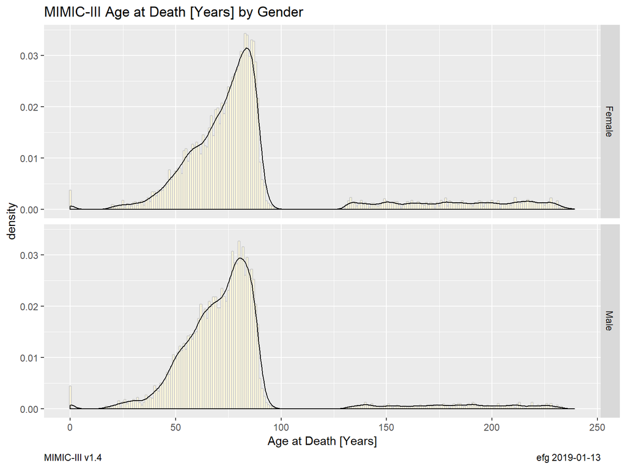

```r
patients                                      %>%
  filter(expire_flag == 1)                    %>%
  select(-dod_hosp, -dod_ssn, -expire_flag)   %>%
  collect()                                   %>%
  mutate(AgeAtDeathYears = as.double(dod - dob)/ (86400 * 365.25) )  %>%

  ggplot(aes(x = AgeAtDeathYears, y = ..density..))             +
    geom_histogram(fill="cornsilk", color="grey80", binwidth=1) +
    geom_density()                                              +
    facet_grid(gender ~ ., labeller = as_labeller(facetLabels)) +
    labs(title="MIMIC-III Age at Death [Years] by Gender",
         x = "Age at Death [Years]",
         caption=c(plotCaptionLeft, plotCaptionRight))          +
    theme(plot.caption = element_text(hjust=c(0.0,1.0)))
```

# 6 Close database

```r
dbDisconnect(MimicDB)
```

# 7 Use RPostgreSQL package

RPostgres package does not work correctly with dates before 1970 (fix expected in Feb. 2019). RPostgreSQL handles dates before 1970, but sometimes truncates datetime stamps to dates, which leads to other problems.

## 7.1 Computed: Age at Death [CORRECT results with RPostgreSQL]

```r
library(RPostgreSQL)
MimicDB <- dbConnect(RPostgreSQL::PostgreSQL(),
                     dbname   = "mimic",
                     user     = Sys.getenv("MIMIC_User"),
                     password = Sys.getenv("MIMIC_Password"),
                     options  = "-c search_path=mimiciii")
```

```r
patients <- tbl(MimicDB, in_schema("mimiciii", "patients"))
```

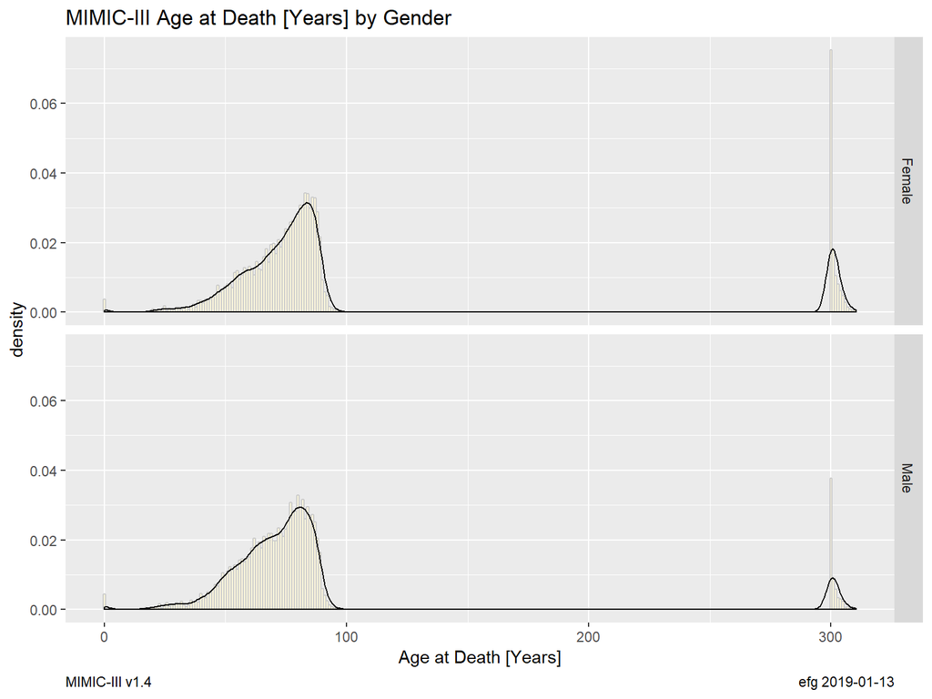

```r
patients                                      %>%
  filter(expire_flag == 1)                    %>%
  select(-dod_hosp, -dod_ssn, -expire_flag)   %>%
  collect()                                   %>%
  mutate(AgeAtDeathYears = as.double(dod - dob)/ (86400 * 365.25) )  %>%

  ggplot(aes(x = AgeAtDeathYears, y = ..density..))             +
    geom_histogram(fill="cornsilk", color="grey80", binwidth=1) +
    geom_density()                                              +
    facet_grid(gender ~ ., labeller = as_labeller(facetLabels)) +
    labs(title="MIMIC-III Age at Death [Years] by Gender",
         x = "Age at Death [Years]",
         caption=c(plotCaptionLeft, plotCaptionRight))          +
    theme(plot.caption = element_text(hjust=c(0.0,1.0)))
```

```r
dbDisconnect(MimicDB)
```

```
[1] TRUE
```

Processing time: 6.0 secs

2019-01-13 0005